# STAT 220 Lab 3 - Exploring Categorical Data

In this lab, we will again make use of the `lattice` and `tidyverse` packages:

```r
library(lattice)
library(tidyverse)
```

## 1. The CDC Data

The Behavioral Risk Factor Surveillance System (BRFSS) is an annual telephone survey of 350,000 people in the United States. As its name implies, the BRFSS is designed to identify risk factors in the adult population and report emerging health trends. For example, respondents are asked about their diet and weekly physical activity, their HIV/AIDS status, possible tobacco use, and even their level of healthcare coverage. The BRFSS Web site (http://www.cdc.gov/brfss) contains a complete description of the survey, including the research questions that motivate the study and many interesting results derived from the data.

We will focus on a random sample of 20,000 people from the BRFSS survey conducted in 2000. While there are over 200 variables in this data set, we will work with a small subset.

The data file can be downloaded at jingshuw.org/materials/stat220/data/cdc.dat. Then set the *working directory* as in Lab01, and load the data using `read.table` as follows.

```r
cdc = read.table("cdc.dat", header=TRUE)
```

If you have trouble setting working directory and loading data file, don’t hesitate to ask TA for help. To view the names of the variables, type the command

```r
str(cdc)
```

This returns the names `genhlth`, `exerany`, `hlthplan`, `smoke100`, `height`, `weight`, `wtdesire`, `age`, and `gender`. Each one of these variables corresponds to a question that was asked in the survey. For example, for `genhlth`, respondents were asked to evaluate their general health, responding either excellent, very good, good, fair or poor. The `exerany` variable indicates whether the respondent exercised in the past month (y) or did not (n). Likewise, `hlthplan` indicates whether the respondent had some form of health coverage (y) or did not (n). The `smoke100` variable indicates whether the respondent had smoked at least 100 cigarettes in her lifetime. The other variables record the respondent’s `height` in inches, `weight` in pounds as well as their desired weight, `wtdesire`, `age` in years, and `gender`.

**Exercise 1:** How many cases are there in this data set? How many variables? For each variable, identify its variable type (e.g. numerical–continuous, numerical– discrete, categorical–ordinal, categorical–nominal).

You could also look at *all* of the data frame at once by typing its name into the console, but that might be unwise here. We know `cdc` has 20,000 rows, so viewing the entire data set would mean flooding your screen. It’s better to take small peeks at the data with `head`, `tail` or the subsetting techniques that you’ll learn in a moment.

## 2. Review of Lab 2

In Lab 2, we have learned how to find numerical summaries in R, like `summary()`, `mean()`, `median()`, `sd()` , `var()` , `min()` , `max()` , `sum()` , `IQR()`, as well as how to make histograms, boxplots, and scatter plots. As a review, let’s consider a new variable that doesn’t show up directly in this data set: Body Mass Index (BMI)(http://en.wikipedia.org/wiki/Body_mass_index). BMI is a weight to height ratio and can be calculated as:

$$\text{BMI} = \frac{\text{weight}~(lb)}{\text{height}~(\text{in})^2} * 703$$

703 is the approximate conversion factor to change units from metric (meters and kilograms) to imperial (inches and pounds).

The following two lines first make a new object called `bmi` and then creates box plots of these values, defining groups by the variable `genhlth`.

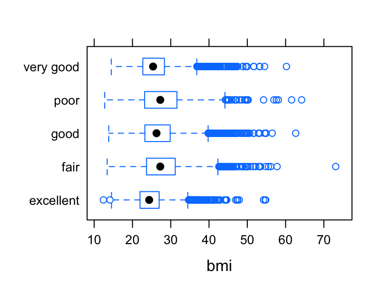

```r
cdc = transform(cdc, bmi = (weight / height^2) * 703)
bwplot(genhlth ~ bmi, data=cdc)
```

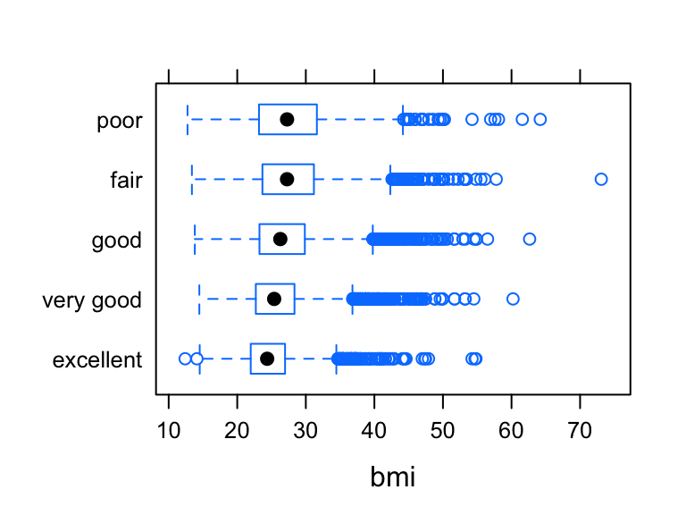

```r
cdc = transform(cdc,
                genhlth = ordered(genhlth,
                levels=c("excellent", "very good", "good", "fair", "poor")))
bwplot(genhlth ~ bmi, data=cdc)
```

Likewise, we can make side-by-side histograms comparing the `bmi` of people with different self-rated health status.

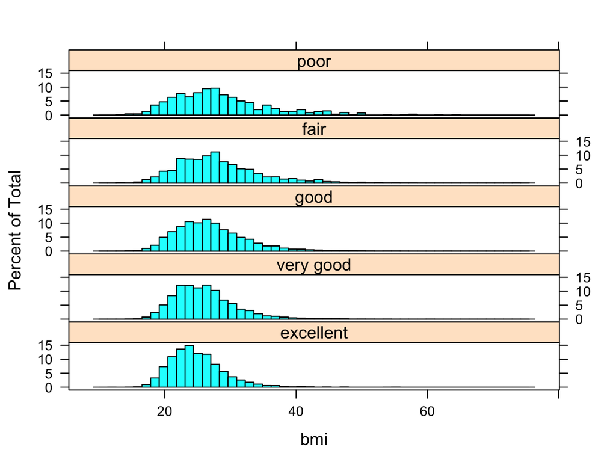

```r
histogram(~ bmi | genhlth, data=cdc, nint=50, layout = c(1,5))
```

We see all 5 histograms are right skewed, and the center of the histograms increase slightly as the health status gets worse.

The following scatterplot of weight versus desired weight.

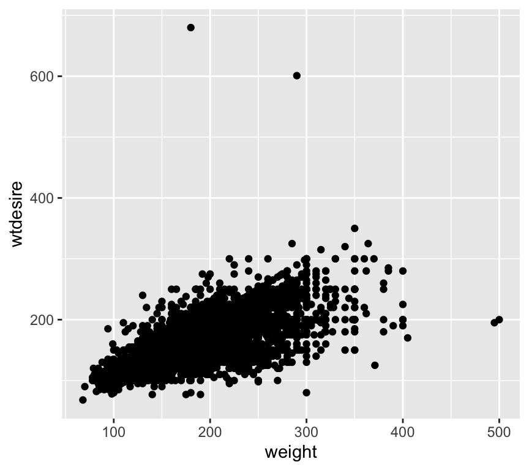

```r
qplot(weight, wtdesire, data=cdc)
```

Apparently there are two outliers, with incredibly large desired weights (the two guys must be kidding). To remove the two outliers so that we take a closer look at big chunk of points, we can remove these two observation from the plot using `subset`.

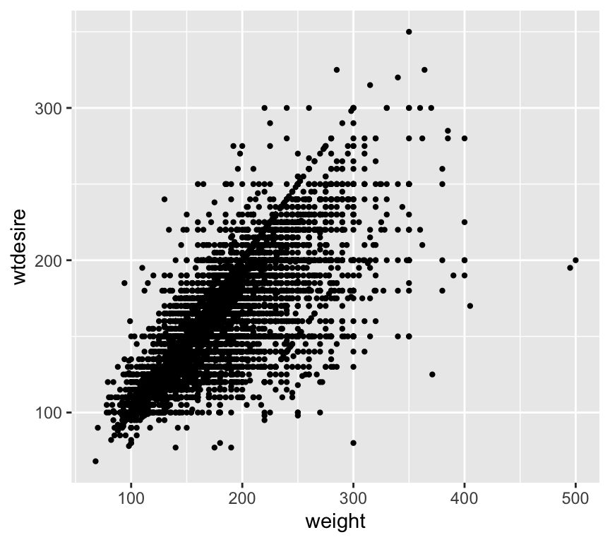

```r
qplot(weight, wtdesire, data=subset(cdc,wtdesire <400), size= I(0.8))
```

**Exercise 2:** Based on the scatterplot, describe the relationship between these two variables.

One can use color of the point to indicate the gender (or other categorical variables) of the subjects.

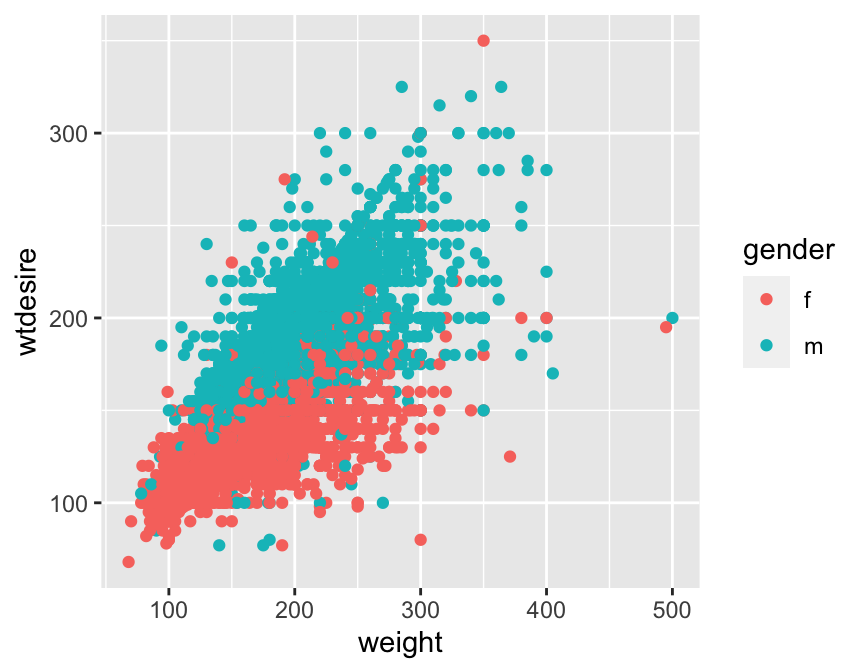

```r
qplot(weight, wtdesire, color=gender, data=subset(cdc,wtdesire <400))
```

Or one can make separate scatterplots of desire weight and true weight for men and women, using `facets`.

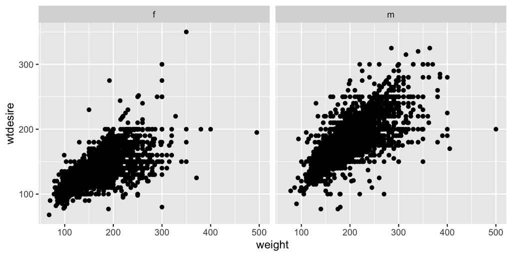

```r
qplot(weight, wtdesire, facets=~gender, data=subset(cdc,wtdesire <400))
```

Note that the two scatter plots are simply labelled `m` and `f`, which are the two levels of the variable `gender.` It would be more clear if they could be labelled `male` and `female` which can be done in R as follows:

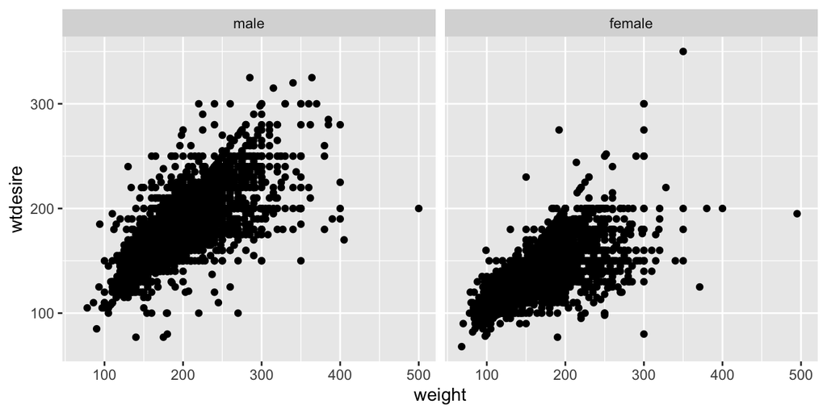

```r
cdc = transform(cdc, gender = ordered(gender, levels=c("m", "f"), labels=c("male","female")))
qplot(weight, wtdesire, facets=~gender, data=subset(cdc,wtdesire <400))
```

We can use the color of points to represent the `bmi` of subjects:

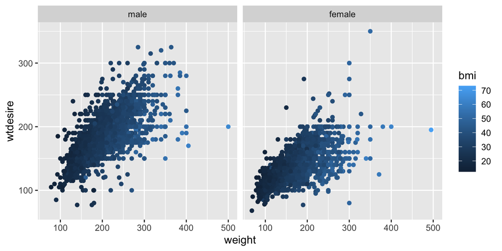

```r
qplot(weight, wtdesire, color=bmi, facets=~gender, data=subset(cdc,wtdesire <400))
```

Not surprisingly, for people with the same desired weight, the higher the actually weight, the heigher their `bmi`.

Finally, we should label the plot properly.

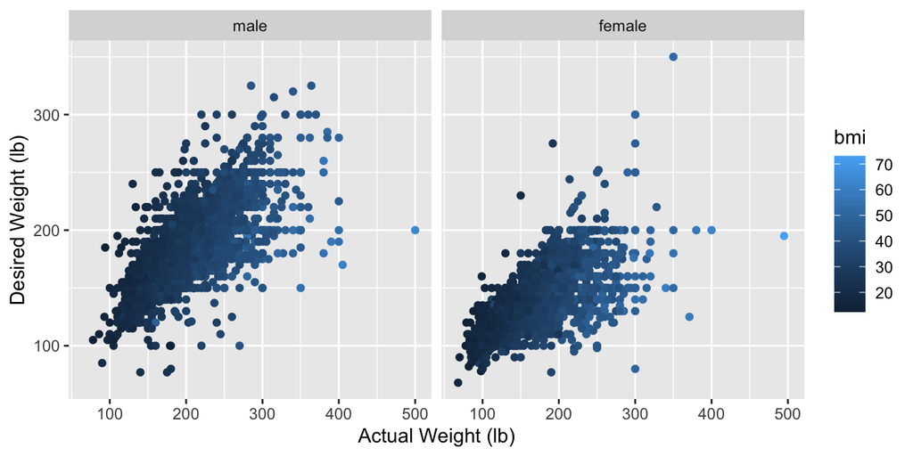

```r
qplot(weight, wtdesire, facets=~gender, color=bmi, data=subset(cdc,wtdesire <400), xlab="Actual Weight (lb)", ylab="Desired Weight (lb)")
```

## 3. Summarizing and Visualizing Categorical Data

### 3.1 Tables

```r
table(cdc$smoke100)
```

```
##
##     n     y
## 10559  9441
```

One can convert the table of counts to proportions by the funstion `prop.table.`

```r
prop.table(table(cdc$smoke100))
```

```
##
##       n       y
## 0.52795 0.47205
```

The `table` command can be used to tabulate any number of variables that you provide. For example, to cross tablulate the two variable `smoke100` and `genhlth`, we could type

```r
table(cdc$smoke100, cdc$genhlth)
```

```
##
##     excellent very good good fair poor
##   n      2879      3758 2782  911  229
##   y      1778      3214 2893 1108  448
```

We can add marginal totals to the two-way table by the `addmargins` command.

```r
addmargins(table(cdc$smoke100, cdc$genhlth))
```

```
##
##       excellent very good  good  fair  poor   Sum
##   n        2879      3758  2782   911   229 10559
##   y        1778      3214  2893  1108   448  9441
##   Sum      4657      6972  5675  2019   677 20000
```

If one wants to view the proportions instead of counts, one can use:

```r
prop.table(table(cdc$smoke100, cdc$genhlth))       # overall proportions
```

```
##
##     excellent very good    good    fair    poor
##   n   0.14395   0.18790 0.13910 0.04555 0.01145
##   y   0.08890   0.16070 0.14465 0.05540 0.02240
```

```r
prop.table(table(cdc$smoke100, cdc$genhlth),1)     # row proportions
```

```
##
##      excellent  very good       good       fair       poor
##   n 0.27265840 0.35590492 0.26347192 0.08627711 0.02168766
##   y 0.18832751 0.34043004 0.30642940 0.11736045 0.04745260
```

```r
prop.table(table(cdc$smoke100, cdc$genhlth),2)     # column proportions
```

```
##
##     excellent very good      good      fair      poor
##   n 0.6182091 0.5390132 0.4902203 0.4512135 0.3382570
##   y 0.3817909 0.4609868 0.5097797 0.5487865 0.6617430
```

The first line gives the overall proportions(dividing the counts by the total number of cases), the second lines gives the row proportions (dividing the counts by the row totals), the last lines gives the column proportions (dividing the counts by the column totals), Likewise, three-way tables cross-tabulating 3 categorical variables can be created as.

```r
table(cdc$smoke100, cdc$genhlth, cdc$gender)
```

```
## , ,  = male
##
##
##     excellent very good good fair poor
##   n      1357      1677 1121  326   66
##   y       941      1705 1601  558  217
##
## , ,  = female
##
##
##     excellent very good good fair poor
##   n      1522      2081 1661  585  163
##   y       837      1509 1292  550  231
```

### 3.2 Bar Plots (or Bar Charts)

Next, we make a bar chart of the entries in the table by putting the table inside the `barchart` command.

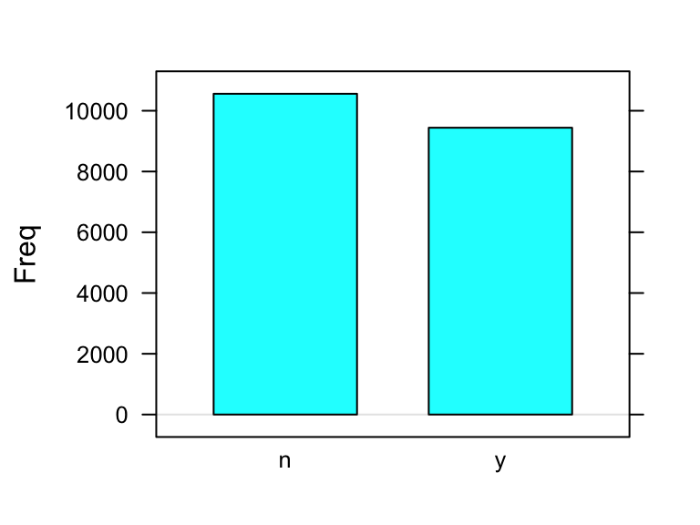

```r
barchart(table(cdc$smoke100), horizontal=FALSE)
```

Notice what we’ve done here! We’ve computed the table of `cdc$smoke100` and then immediately applied the graphical function, `barchart`. This is an important idea: R commands can be nested. You could also break this into two steps by typing the following:

```r
smoke = table(cdc$smoke100)
barchart(smoke, horizontal=FALSE)
```

Here, we’ve made a new object, a table, called `smoke` (the contents of which we can see by typing `smoke` into the console) and then used it in as the input for `barchart`. The special symbol `=` performs an *assignment*, taking the output of one line of code and saving it into an object in your workspace.  
This is another important idea that we’ll return to later.

To create a segmented bar chart representing a two-way table, we can create the two-way table first, and then `barchart` the table.

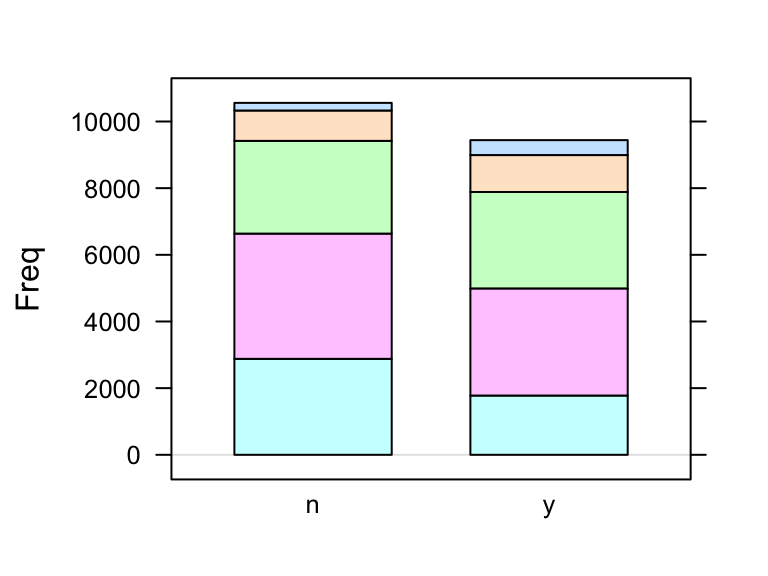

```r
smoke.hlth = table(cdc$smoke100, cdc$genhlth)
barchart(smoke.hlth, horizontal=FALSE)
```

To get the standardized version of the barchart above (standardized the heights of all the bars), we can first convert the table to proportions and then make `barchart` it.

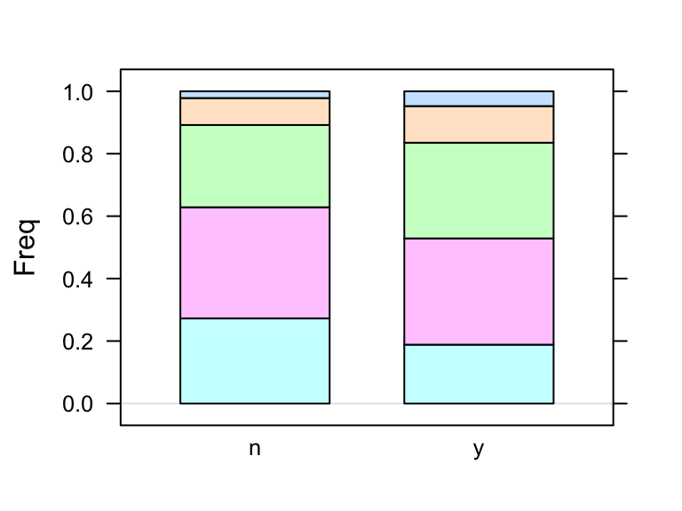

```r
barchart(prop.table(smoke.hlth,1), horizontal=FALSE)
```

In the barcharts above, it’s better to add a legend for the colors used. One can add a legend using the `auto.key` option.

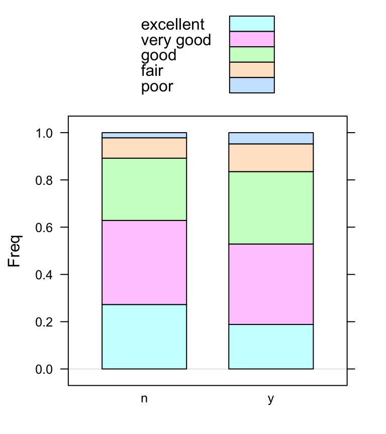

```r
barchart(prop.table(smoke.hlth,1), horizontal=FALSE, auto.key=TRUE)
```

The default location of the legend is on the top. To move the legend to the right, and to add an title to it, one can do the following

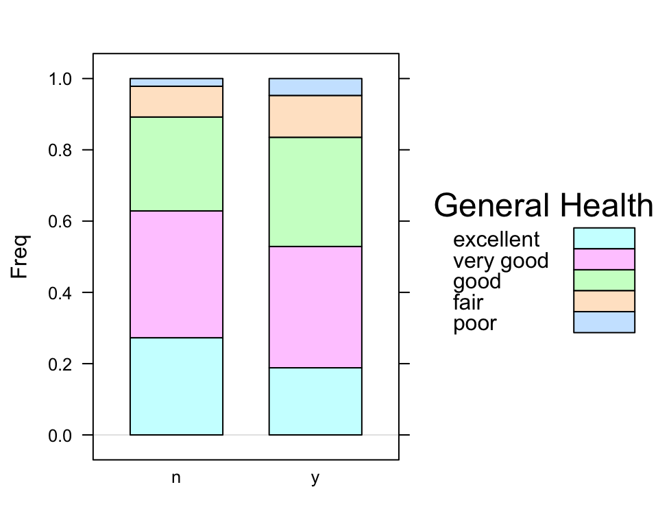

```r
barchart(prop.table(smoke.hlth,1), horizontal=FALSE,
         auto.key=list(space="right", title="General Health"))
```

From the above, we can see the size of the legend title is too big. We can adjust the size of the legend title as follows.

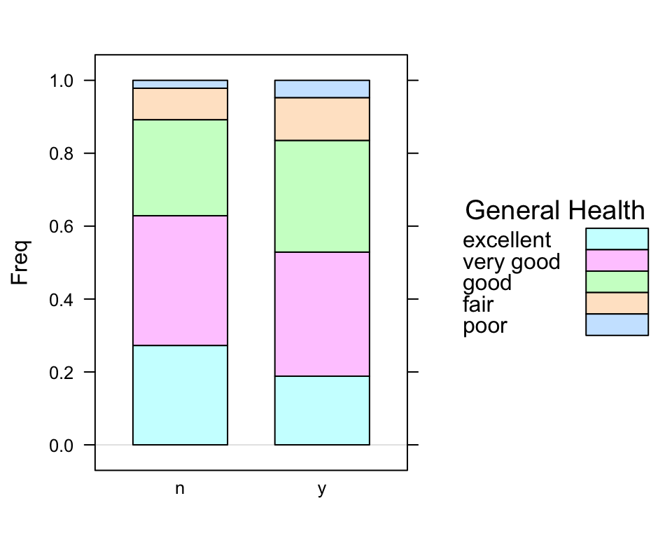

```r
barchart(prop.table(smoke.hlth,1), horizontal=FALSE,
         auto.key=list(space="right", title="General Health",cex.title=1.2))
```

**Exercise 3:** Compute the relative frequency distribution for ‘gender’ and ‘genhlth’. How many males are in the sample? What proportion of the sample reports being in excellent health?

### 3.3 Mosaic Plots

To investigate whether exercise has any effect on what people feel about their general health, we may look at the two-way table

```r
exer.hlth = table(cdc$exerany, cdc$genhlth)
```

To create a mosaic plot of this table, we would enter the following command.

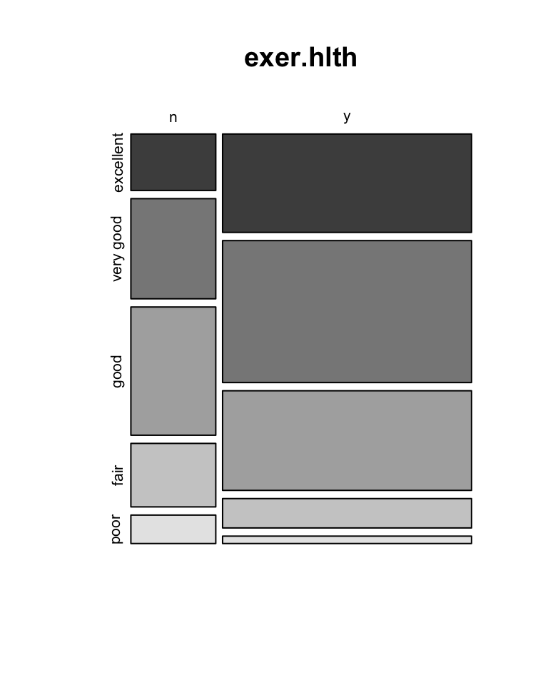

```r
mosaicplot(exer.hlth, color=TRUE)
```

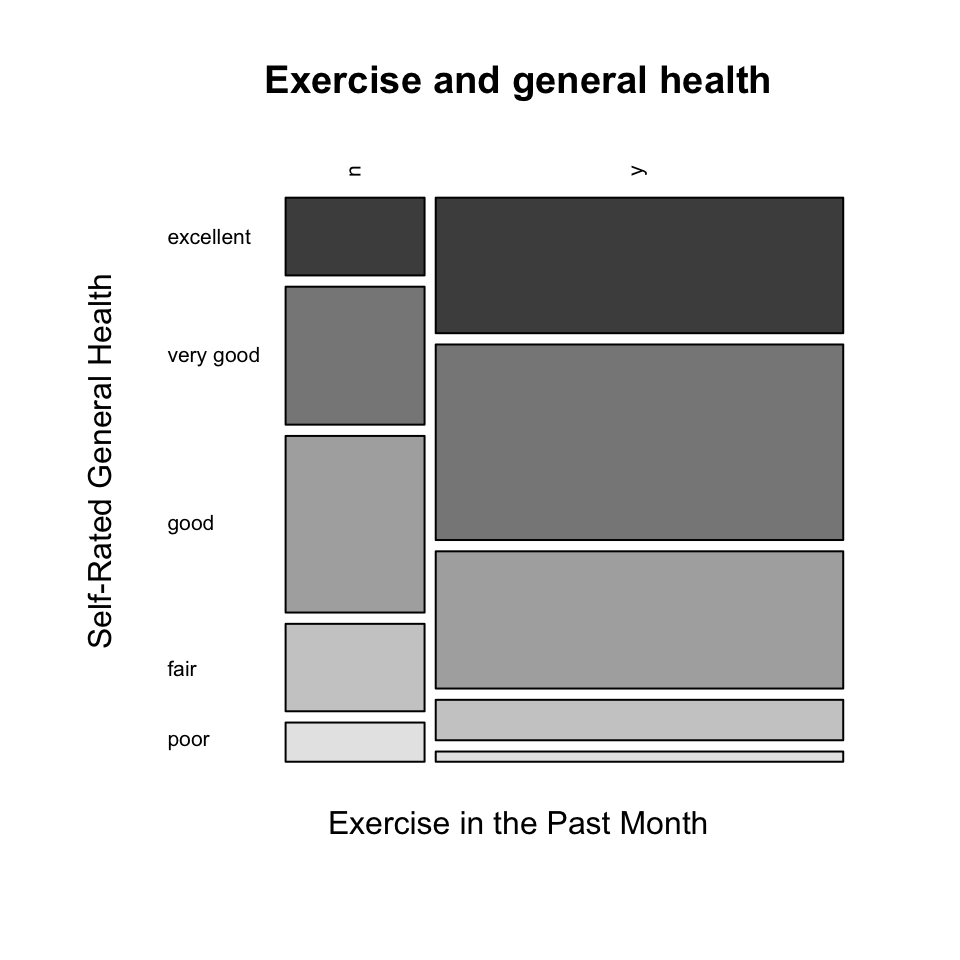

```r
mosaicplot(exer.hlth,
           main="Exercise and general health",
           ylab="Self-Rated General Health",
           xlab="Exercise in the Past Month",
           las=2, color=TRUE)
```

## 4.Subsetting

It’s often useful to extract all individuals (cases) in a data set that have specific characteristics. We accomplish this through *conditioning* commands. First, consider expressions like

```r
cdc$gender == "m"
```

or

```r
cdc$age > 65
```

These commands produce a series of `TRUE` and `FALSE` values. There is one value for each respondent, where `TRUE` indicates that the person was male (via the first command) or older than 65 (second command).

Suppose we want to extract just the data for the men in the sample, or just for those over 30. We can use the R function `subset` to do that for us. For example, the command

```r
mdata = subset(cdc, gender == "male")
```

will create a new data set called `mdata` that contains only the men from the `cdc` data set. In addition to finding it in your workspace alongside its dimensions, you can take a peek at the first several rows as usual

```r
head(mdata)
```

This new data set contains all the same variables but just under half the rows. It is also possible to tell R to keep only specific variables, which is a topic we’ll discuss in a future lab. For now, the important thing is that we can carve up the data based on values of one or more variables.

As an aside, you can use several of these conditions together with `&` and `|`. The `&` is read “and” so that

```r
m_and_over65 = subset(cdc, gender == "male" & age > 65)
```

will give you the data for men over the age of 65. The `|` character is read “or” so that

```r
m_or_over65 = subset(cdc, gender == "male" | age > 65)
```

will take people who are men or over the age of 65 (who are males eligible to Medicare). In principle, you may use as many “and” and “or” clauses as you like when forming a subset, and we might be interested in their self-rated health status and exercise activity.

```r
exer.hlth.over65 = exer.hlth = table(m_or_over65$exerany, m_or_over65$genhlth)
mosaicplot(exer.hlth.over65,
           main="Male Over 65",
           ylab="Self-Rated General Health",
           xlab="Exercise in the Past Month",
           las=2,
           color=TRUE)
```

[output not shown]

**Exercise 5:** Create a new object called `under23_and_smoke` that contains all observations of respondents under the age of 23 that have smoked 100 cigarettes in their lifetime. Write the command you used to create the new object as the answer to this exercise. What percentage of them are males? What percentage of them exercise at least once in the past month?

## 5. Ending

At this point, we’ve done a good first pass at analyzing the information in the BRFSS questionnaire. We’ve found an interesting association between smoking and gender, and we can say something about the relationship between people’s assessment of their general health and their own BMI. We’ve also picked up essential computing tools – summary statistics, subsetting, and plots – that will serve us well throughout this course.

## 6. On Your Own

- Let’s consider a new variable: the difference between desired weight (`wtdesire`) and current weight (`weight`). Create this new variable by subtracting the two columns in the data frame and assigning them to a new object called `wdiff`.
- What type of data is `wdiff`? If an observation `wdiff` is 0, what does this mean about the person’s weight and desired weight. What if `wdiff` is positive or negative?
- Describe the distribution of `wdiff` in terms of its center, shape, and spread, including any plots you use. What does this tell us about how people feel about their current weight?
- Using numerical summaries and a side-by-side box plot, determine if men tend to view their weight differently than women.
- Now it’s time to get creative. Find the mean and standard deviation of `weight` and determine what proportion of the weights are within one standard deviation of the mean.

### Disclaimer

This lab was expanded for STAT 220 by Yibi Huang from a lab released from OpenIntro by Andrew Bray and Mine Çetinkaya-Rundel, which originally was based on a lab written by Mark Hansen of UCLA Statistics. This lab can be shared or edited under a [Creative Commons Attribution-ShareAlike 3.0 Unported licence](http://creativecommons.org/licenses/by-sa/3.0).